# paper-review

## Paper Review

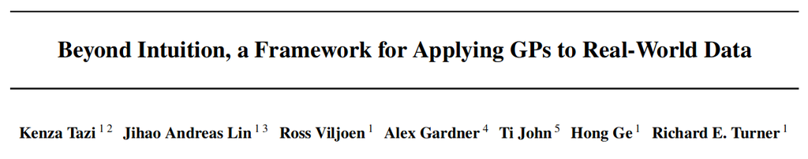

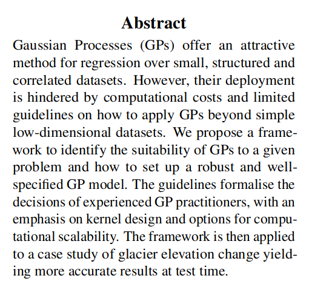

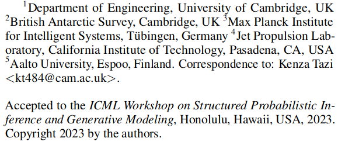

## Summary

- A brief overview of Gaussian Processes and their pros/cons.
- Ten step framework for setting up a “robust and well-specified” model.
- Case study of interpolating glacial elevation data collected by satellites over Greenland.
- A engineering technical manual rather than a mathematical treatise.

## Some GP equations

$\{{\mathbf{x}_i, y_i}\}$ for $i = 1, \ldots, N$, $\mathbf{x}_i \in \mathbb{R}^d$ and $y_i \in \mathbb{R}$.

$$y_i = f(\mathbf{x}_i) + \varepsilon_i, \quad e_i \sim \mathcal{N}(0, \sigma^2_n)$$

$$f(.) \sim\mathcal{GP} \left( \mu(\mathbf{x};\mathbf\theta_\mu), k(\mathbf{x}, \mathbf{x'}; \mathbf{\theta}_k) \right)$$

# Strengths & Limitations of GPs

## Strengths

- Well-calibrated uncertainty estimates
- Handles data that is not IID
- More interpretable than ML
- Data-efficient when retraining (?)
  - More to do with Bayesian workflow than GPs.
- Unlikely to fail (?)
  - Reliable as a subpart of a broader ML system.

## Limitations

- Training on large datasets ($N \gtrsim 10^4$) is prohibitive
  - Covariance Matrix inversion is $\mathcal{O}(N^3)$
- Training on high-dimensional data ($D \gtrsim 100$) is challenging
  - Covariance function scales at $\mathcal{O}(DN^2)$
- Risk of overfitting (?)
  - Complex kernel functions with many parameters.
- Non-Gaussian distributions (?)
- Model misspecification (?)

## Framework

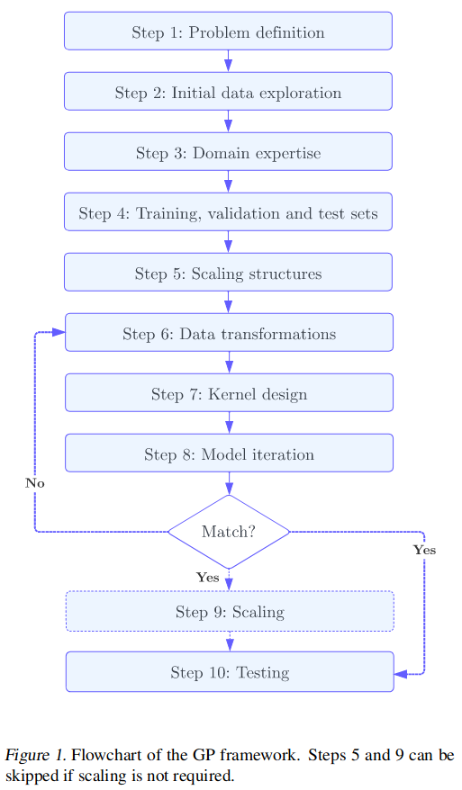